# Time Series Decomposition

2024-02-04

## What is a time series?

- A time series is a group of observations of a data point that are tracked over time
  - Trend/Cycle
  - Seasonal
  - Remainder
- This information can be tracked at several levels of time (e.g. annual, quarterly, monthly, etc.)
- Economic measures are generally the most common metrics tracked and discussed, but any area with relevant data points can be analyzed

## Why is Time Series Decomposition relevant?

- It is helpful to understand the patterns that make up trends/cycles vs seasonal behaviors.
- Different modeling techniques can be applied based on the knowledge of how the primary components interact with one another.
- If you are interested in making inferences on this data, it is a good starting point to get a better understanding of these elements

## Our Dataset

```
## # A tsibble: 6 x 5 [1h] <UTC>
## # Key:       start_station_name, rideable_type, member_casual [6]
## # Groups:    start_station_name, rideable_type @ start_time [6]
##   start_time          start_station_name rideable_type member_casual
##   <dttm>              <chr>              <chr>         <chr>
## 1 2023-09-12 08:00:00 1 Ave & E 30 St    classic_bike  member
## 2 2023-06-22 00:00:00 1 Ave & E 62 St    classic_bike  member
## 3 2023-05-25 08:00:00 1 Ave & E 68 St    classic_bike  member
## 4 2023-05-26 11:00:00 10 Ave & W 28 St   classic_bike  member
## 5 2023-10-18 18:00:00 11 Ave & W 27 St   classic_bike  member
## 6 2023-06-11 15:00:00 11 Ave & W 59 St   classic_bike  member
## # ℹ 1 more variable: number_of_rides <int>
```

## Viewing our Data

It’s always a good idea to plot your time series prior to any sort of decomposition

[figure not shown]

## Plotting Seasonality

Below is the seasonal plot of our data for a daily period. We see a higher number of rides around 5-6pm, when many people are commuting.

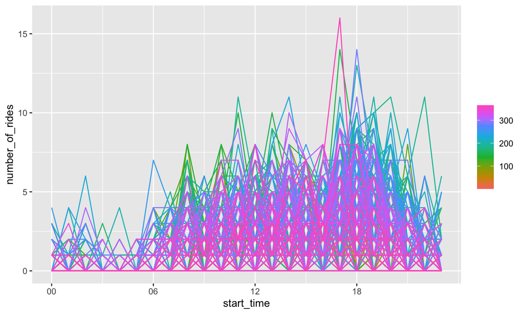

## Time Series Components

- Our example time-series data has two seasonal periods: daily and weekly
- We can plot the different `components` of our decomposed series via the `autoplot` function

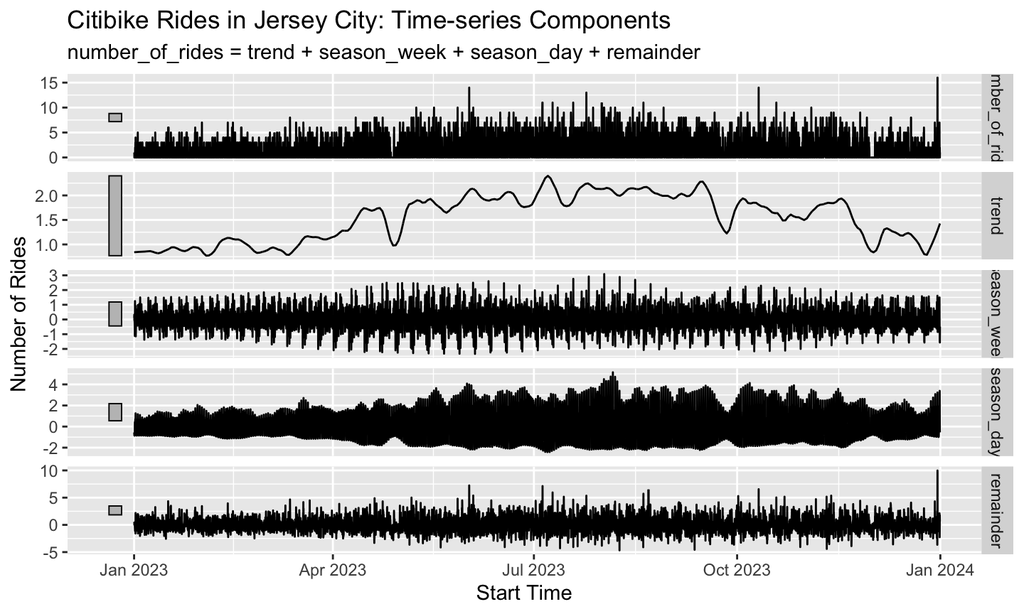

## Time Series Components

- We can also seasonally-adjust our data easily in the `fabletools` package

[figure not shown]

## Viewing Daily Rides by Membership

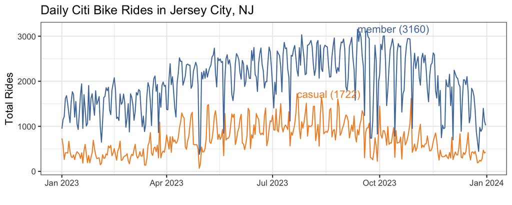

Membership Type

| Type | Date | Max Daily Rides | Total Rides |
| --- | --- | --- | --- |
| member | 2023-09-12 | 3160 | 731783 |
| casual | 2023-07-22 | 1722 | 257068 |

## Moving Averages

- Useful for “smoothing” data to reduce seasonal fluctuations and discover the trend-cycle.

\[k = \frac {(m-1)}{2}\]

\[a_j = a_{-j}\]

## Calculating for 01/04/2023

| member_casual | datetime | total_member_rides | 7-MA |
| --- | --- | --- | --- |
| casual | 2023-01-01 | 732 | NA |
| casual | 2023-01-02 | 582 | NA |
| casual | 2023-01-03 | 265 | NA |
| casual | 2023-01-04 | 412 | 497.4286 |
| casual | 2023-01-05 | 418 | 456.0000 |
| casual | 2023-01-06 | 405 | 419.4286 |
| casual | 2023-01-07 | 668 | 425.4286 |

## Calculating for 12/28/2023

| member_casual | datetime | total_member_rides | 7-MA |
| --- | --- | --- | --- |
| casual | 2023-12-25 | 207 | 277.2857 |
| casual | 2023-12-26 | 247 | 281.0000 |
| casual | 2023-12-27 | 227 | 290.7143 |
| casual | 2023-12-28 | 286 | 325.0000 |
| casual | 2023-12-29 | 472 | NA |
| casual | 2023-12-30 | 407 | NA |
| casual | 2023-12-31 | 429 | NA |

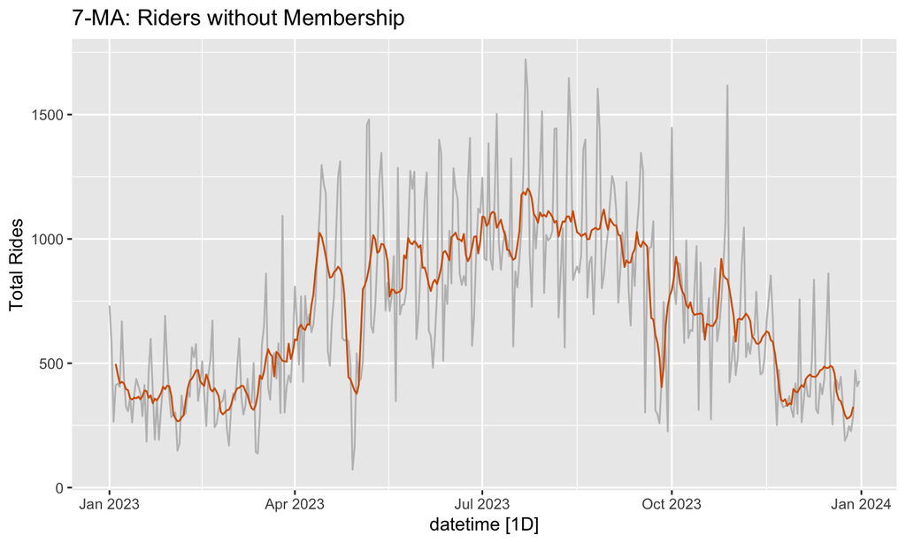

## Moving Average is Even Ordered

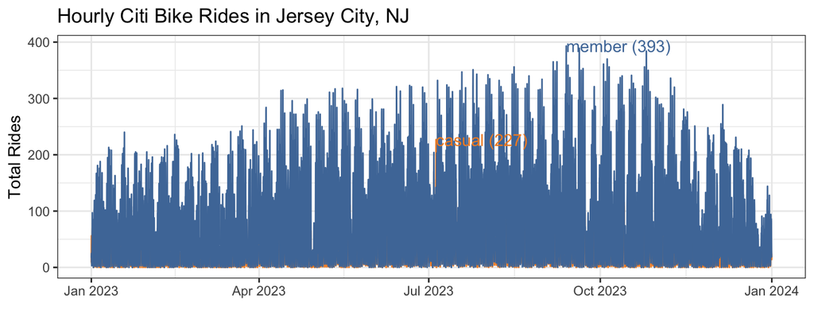

Membership Type

| Type | Hour | Max Daily Rides | Total Rides |
| --- | --- | --- | --- |
| member | 2023-09-12 18:00:00 | 393 | 731783 |
| casual | 2023-07-04 22:00:00 | 227 | 257068 |

## Calculating for 01/01/2023 12:00:00 PM

| member_casual | datetime | total_member_rides | 24-MA | 2x24-MA |
| --- | --- | --- | --- | --- |
| casual | 2023-01-01 07:00:00 | 5 | NA | NA |
| casual | 2023-01-01 08:00:00 | 4 | NA | NA |
| casual | 2023-01-01 09:00:00 | 20 | NA | NA |
| casual | 2023-01-01 10:00:00 | 21 | NA | NA |
| casual | 2023-01-01 11:00:00 | 47 | 30.50000 | NA |
| casual | 2023-01-01 12:00:00 | 51 | 30.41667 | 30.45833 |
| casual | 2023-01-01 13:00:00 | 70 | 28.29167 | 29.35417 |
| casual | 2023-01-01 14:00:00 | 58 | 27.37500 | 27.83333 |
| casual | 2023-01-01 15:00:00 | 66 | 26.91667 | 27.14583 |

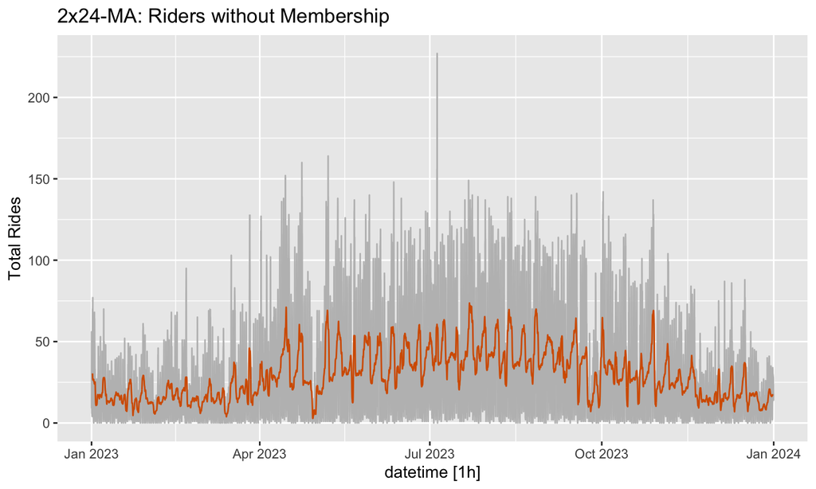

## Classical Decomposition Methods

- Additive Decomposition: \(Y = S + T + C\)
  - Calculate Trend-Cycle Component \(T_t\) = 2 x m-MA (even) or m-MA (odd)
  - Detrended Series = \(y_t - T_t\)
  - Seasonal Series = Average of the seasonal component (month, quarter, etc)
  - Remainder (Irregular) Series = \(R_t = y_t - T_t - S_t\)

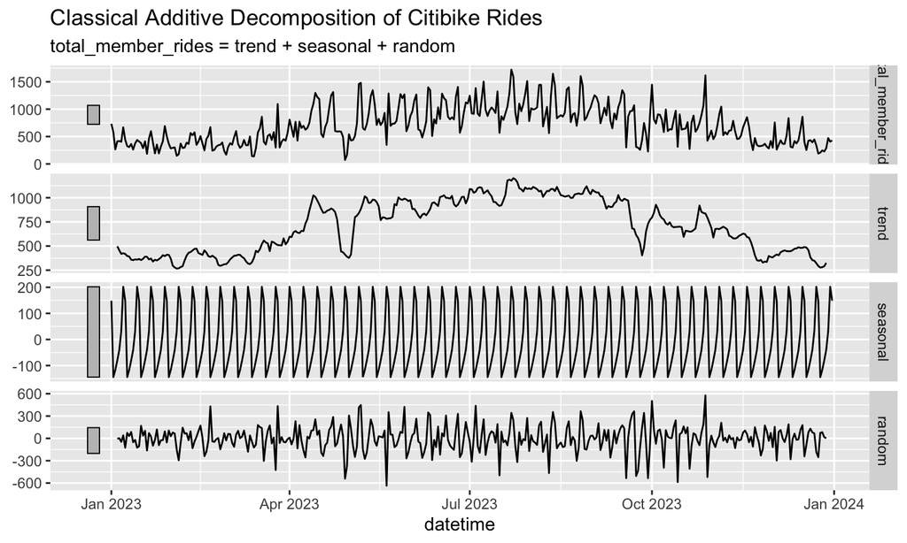

- Multiplicative: \(Y = S * T * C\)
  - Calculate Trend-Cycle Component \(T_t\) = 2 x m-MA (even) or m-MA (odd)
  - Detrended Series = \(\frac{y_t}{T_t}\)
  - Seasonal Series = Average of the seasonal component (month, quarter, etc)
  - Remainder (Irregular) Series = \(R_t = \frac{y_t}{T_t * S_t}\)

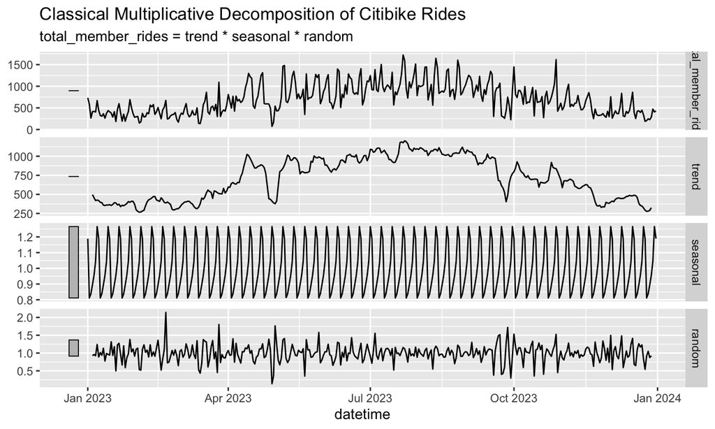

## Classical Decomposition Drawbacks

- The estimated trend-cycle is missing for the first and last few observations
- The trend cycle can be smoothed too much with large, fast peaks and valleys
- We assume the seasonality holds true between each year
- It is not robust to valid outliers such as natural disasters or economic changes.

## STL Decomposition

- *Seasonal and Trend Decomposition using LOESS*
- Use `trend` and `season` parameters to control how rapidly seasonality and trend change

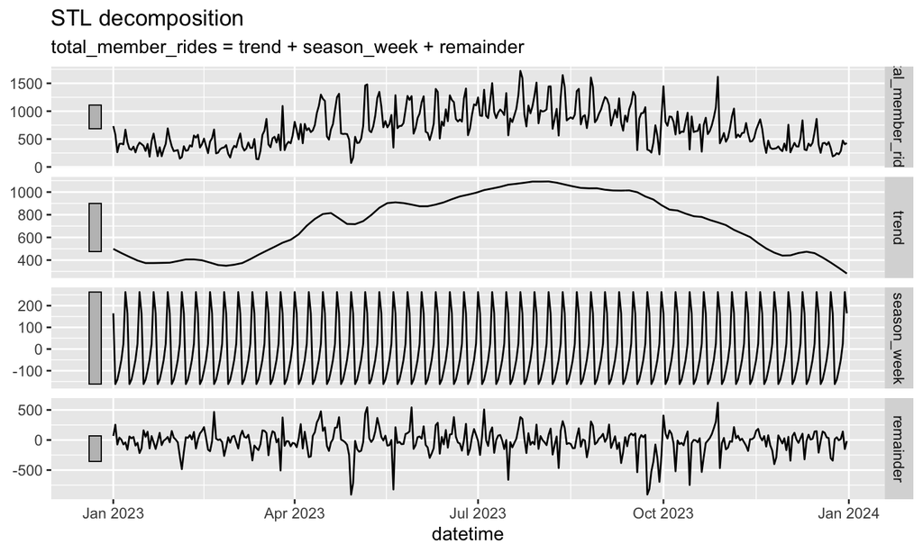

## Pros and Cons of STL Decomposition

#### Pros

- Can handle different types of seasonality well (not just monthly/quarterly)
- User has a lot of control over parameters (smoothness, windowing, etc)
- Robust to outlier values

#### Cons

- Only can be used with additive decomposition
- Doesn’t handle calendar variation automatically
  - [Here’s an article with a newer method that handles multiple seasonalities well!](https://www.sciencedirect.com/science/article/abs/pii/S0096300322004726)

#### Alternative Approaches

- Since economists spend most of their time analyzing time series data, they have come up with additional methods
  - X11/SEATS
    - Primarily handles monthly and quarterly data, but allows for incorporation of holidays.
    - Variation of the seasonal period is allowed
  - DSA
    - German Bank established this method to handle daily data
    - Combines STL on multiple seasonal components and ARIMA for additional handling of outliers and calendar adjustments

## Sources Used

- Hyndman, R.J., & Athanasopoulos, G. (2021) Forecasting: principles and practice, 3rd edition, OTexts: Melbourne, Australia. OTexts.com/fpp3. Accessed on February 16th, 2024
- Oscar Trull, J. Carlos García-Díaz, A. Peiró-Signes, Multiple seasonal STL decomposition with discrete-interval moving seasonalities, Applied Mathematics and Computation, Volume 433, 2022, 127398, ISSN 0096-3003, [https://doi.org/10.1016/j.amc.2022.127398](https://www.sciencedirect.com/science/article/pii/S0096300322004726)
- https://cran.r-project.org/web/packages/dsa/dsa.pdf
- https://towardsdatascience.com/seasonal-adjustment-of-daily-time-series-1bd2aa9b096d